# R Notebook

```r
setwd(dir = "/Users/david_salazarv/GitHub/tidy-data/case-study")
library(reshape2)
library(ggplot2)
library(plyr)
library(stringr)
library(MASS)
library(dplyr)
library(tidyr)
library(readr)
library(tibble)
```

```r
deaths <- read_rds("deaths.rds")
deaths <- as_tibble(deaths) %>%
            filter(yod == 2008, mod != 0, dod != 0)
deaths
```

```
# A tibble: 527,429 x 5
     yod   mod   dod   hod   cod
   <int> <int> <int> <int> <chr>
1   2008     1     1     1   B20
2   2008     1     1     1   B22
3   2008     1     1     1   C18
4   2008     1     1     1   C34
5   2008     1     1     1   C50
6   2008     1     1     1   C50
7   2008     1     1     1   C61
8   2008     1     1     1   E11
9   2008     1     1     1   E11
10  2008     1     1     1   E14
# ... with 527,419 more rows
```

Reproduce Mr. Wickham’s first plot: number of deaths per hour, for all causes of death.

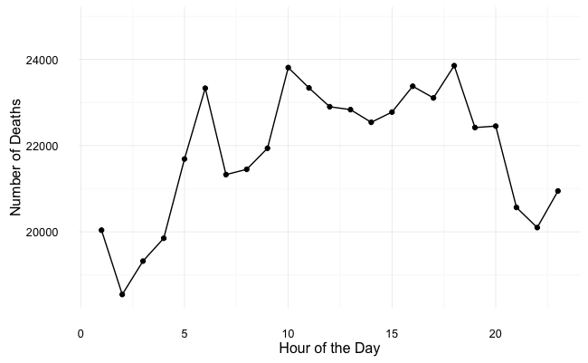

```r
deaths %>%
  group_by(hod) %>%
  summarise(count = n()) %>%
  ggplot(mapping = aes(x = hod, y = count)) +
  geom_line() + geom_point() +
  ylab("Number of Deaths") +
  xlab("Hour of the Day") +
  theme_minimal()
```

First, we count the number of deaths in each hour (hod) for each cause (cod):

```r
(per_hod_cod <- deaths %>%
  group_by(hod, cod) %>%
  summarise(count = n()) %>%
  filter(!is.na(hod)))
```

```
Source: local data frame [15,477 x 3]
Groups: hod [23]

     hod   cod count
   <int> <chr> <int>
1      1   A01     3
2      1   A02     3
3      1   A04     7
4      1   A05     1
5      1   A06     2
6      1   A09   111
7      1   A15     2
8      1   A16    53
9      1   A17     2
10     1   A18     5
# ... with 15,467 more rows
```

```r
codes <- read_csv("icd-main.csv")
table_b <- per_hod_cod %>%
  left_join(codes, by = c("cod"="code")) %>%
  arrange(desc(count))
```

```r
options(digits = 1)
with_prop <- deaths %>%
  group_by(cod) %>%
  summarise(count_code = n()) %>%
  right_join(table_b, by = "cod") %>%
  mutate(prop = count/count_code)
```

We then compute the overall average death rate for each hour, and merge that back into the original dataset.

```r
(omg <- deaths %>%
  group_by(hod) %>%
  summarise(freq_all = n()) %>%
  mutate(prop_all = freq_all/sum(freq_all)) %>%
  right_join(with_prop, by = "hod"))
```

```
# A tibble: 15,546 x 8
     hod freq_all prop_all   cod count_code count                                 disease  prop
   <int>    <int>    <dbl> <chr>      <int> <int>                                   <chr> <dbl>
1     10    23811     0.05   I21      47676  2363             Acute myocardial infarction  0.05
2      6    23333     0.04   I21      47676  2194             Acute myocardial infarction  0.05
3     17    23107     0.04   I21      47676  2192             Acute myocardial infarction  0.05
4     16    23378     0.04   I21      47676  2165             Acute myocardial infarction  0.05
5      8    21450     0.04   I21      47676  2155             Acute myocardial infarction  0.05
6      9    21939     0.04   I21      47676  2153             Acute myocardial infarction  0.05
7     18    23856     0.05   I21      47676  2147             Acute myocardial infarction  0.05
8     15    22778     0.04   I21      47676  2116             Acute myocardial infarction  0.04
9     11    23339     0.04   E11      43222  2095 Non-insulin-dependent diabetes mellitus  0.05
10     7    21327     0.04   I21      47676  2087             Acute myocardial infarction  0.04
# ... with 15,536 more rows
```

Next we compute a distance between the temporal pattern of each cause of death and the overall temporal pattern.

```r
(devi <- omg %>%
        group_by(cod) %>%
        summarise(n = sum(count),
                dist = mean((prop-prop_all)^2)) %>%
        filter(n > 50))
```

```
# A tibble: 443 x 3
     cod     n  dist
   <chr> <int> <dbl>
1    A02    62 7e-04
2    A04   137 2e-04
3    A06    82 4e-04
4    A09  3016 3e-05
5    A15   203 2e-04
6    A16  1642 3e-05
7    A17    95 5e-04
8    A18    92 5e-04
9    A19   146 3e-04
10   A41  4120 1e-05
# ... with 433 more rows
```

We don’t know the variance characteristics of this estimator, but we can explore it visually by plotting n vs. deviation

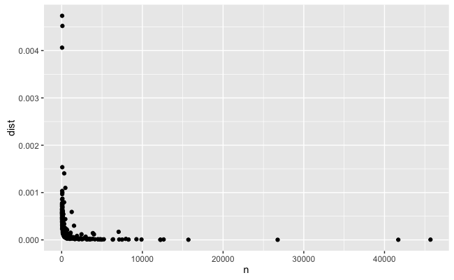

```r
devi %>%
  ggplot(mapping = aes(x = n, y = dist)) +
  geom_point()
```

It seems that the distance decreases as the sample size increases, but not much else. Let’s try a logarithmic scale:

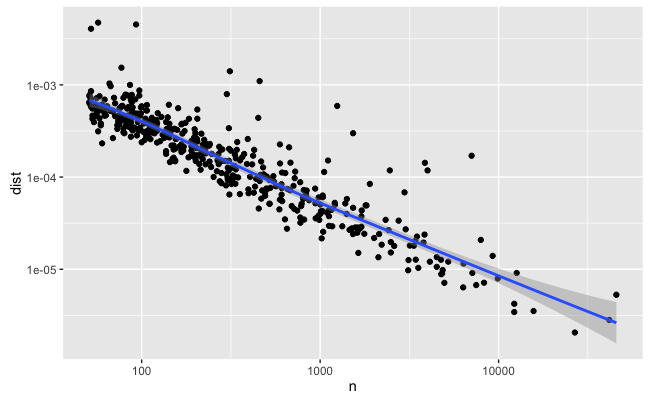

```r
devi %>%
  ggplot(mapping = aes(x = n, y = dist)) +
  geom_point() +
  scale_x_log10() +
  scale_y_log10() +
  geom_smooth()
```

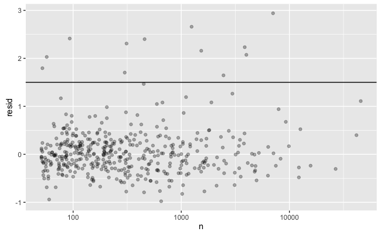

```r
devi$resid <- resid(rlm(log(dist) ~ log(n), data = devi))
devi %>%
  ggplot(mapping = aes(x = n, y = resid)) +
  geom_point(alpha = 0.3) +
  scale_x_log10() +
  geom_hline(yintercept = 1.5)
```

```r
(devi_350 <- devi %>%
  filter(n > 350))
```

```
# A tibble: 172 x 4
     cod     n  dist resid
   <chr> <int> <dbl> <dbl>
1    A09  3016 3e-05  0.35
2    A16  1642 3e-05 -0.18
3    A41  4120 1e-05 -0.18
4    B18   716 5e-05 -0.40
5    B20  2599 2e-05 -0.19
6    B22   416 1e-04  0.23
7    B23  1020 2e-05 -0.82
8    B24   720 1e-04  0.37
9    C15   868 6e-05 -0.01
10   C16  5222 1e-05  0.03
# ... with 162 more rows
```